BIOMEDICAL PROGRAMMING · WEEK 07

# 인체계측 지표와 근감소증 로지스틱 회귀와 진단 성능

NHANES 2011–2018 · 논문 이해부터 가중 회귀와 ROC 검토까지 · 실행 candidate_20261108_v2

**정확 재현 미완료 · 공개 자료의 후보 분석**  
저자의 선정·질환 정의·가중치·예측모형이 충분히 식별되지 않아, 아래 결과는 논문 수치와 단순 대조한 분석자 후보입니다. 연관과 동시점 구분 능력이며 인과효과나 미래 발병 예측으로 단정할 수 없습니다.

논문 최종 대상자**8,159명**

후보 완전사례**8,086명**

SA / SO 후보 사건**687 / 479**

훈련 / 내부 검증**6,468 / 1,618**

단계 01

CONCEPT · 일반 개념

# 연구 질문과 한 사람의 자료

NHANES는 여러 단계로 사람을 추출한 횡단면 조사다. 한 행은 한 참가자이며 SEQN으로 인구학, 검사, 식이, 설문을 연결한다. 결과는 같은 시점의 낮은 근육량 분류와 지표 사이의 연관 및 구분 능력이다. 미래에 생길 질병이나 원인 효과를 직접 보여주지 않는다.

예를 들어 한 사람의 허리둘레가 90 cm, 키가 170 cm면 WHtR=0.90/1.70≈0.529다. 이 값은 개인의 입력이다. 회귀 OR과 ROC는 전체 사람들의 자료로 계산하며 이 예시 한 사람의 효과가 아니다.

BMI가 질환 기준과 지표에 동시에 들어가면 변수들이 정의상 정보를 공유한다. 이때 높은 판별력이 지표의 독립적인 임상적 유용성만을 의미하지 않는다.

PAPER · 논문과 자료

# 논문의 자료와 후보 집단

PDF 2–4쪽: 2011–2018 DXA 자료를 주 분석에 사용하고, 논문 Figure 1의 39,156명에서 최종 8,159명을 선정했다. 2001–2004 BIA는 별도 검증이다. SA 기준은 근육량/BMI 남성 <0.789, 여성 <0.512이고 SO는 SA와 BMI ≥30이다. 임상 진단 전체와는 구별한다.

이번 후보는 사지 제지방량 합을 근육량 대용으로 썼으며, 논문에서 정확한 DXA 변수 조합은 확인되지 않았다. 기본 측정가능자 10,745명에서 모든 후보 공변량 및 양의 2일 식이가중치가 있는 8,086명을 선택했다. 이 중 SA 687명, SO 479명이다. 논문의 세부 선정 및 건강변수 코딩이 미보고여서 73명 차이의 원인을 특정할 수 없다.

후보 공변량은 `../analysis/data/derived/covariates_candidate_설명.md`를 확인한다. 당뇨·고혈압·고콜레스테롤 자가보고는 논문 변수와 일치가 검증되지 않은 대체치다.

단계 02

CONCEPT · 일반 개념

# 가중 로지스틱 회귀 읽기

로짓은 log(p/(1−p))이고 지표 계수 β를 지수화한 exp(β)가 해당 지표의 정해진 증가 단위에 대한 오즈비(OR)다. OR 1.5는 다른 변수 고정 시 오즈가 1.5배라는 뜻이며, 위험확률이 반드시 1.5배라는 뜻은 아니다. 95% CI는 추정의 불확실성을 보여준다. p값은 귀무가설과 자료의 불일치 정도이며 효과의 크기나 인과성 자체가 아니다.

가중치는 표본의 대표성을 조정하고, 층·PSU는 불확실성을 계산할 때 조사 설계에 반영한다. 단순 가중 GLM의 기본 표준오차는 층화·군집을 반영한 표준오차와 같다고 가정할 수 없다. 선택된 사람만 남긴 뒤 설계 밖 PSU를 없애지 않도록 도메인 분석에 주의한다.

PAPER · 논문과 자료

# Table 3: 후보 회귀와 원문

논문 모델 1은 단변량, 2는 인구학 변수, 3은 건강·활동·식이를 추가한다. 이번 분석은 세 모델 모두 동일한 8,086명 완전사례에 2일 식이가중치 WTDR2D/4를 사용했다. 가중 우도에 층별 PSU 점수의 Taylor 선형화 분산과 t 자유도를 적용했다. 저자의 실제 가중치와 공변량 세부 정의는 확인되지 않았다.

예: SA의 BRI 1 증가당 모델 3 OR은 **1.709 (95% CI 1.614–1.809, p<0.001)**, 논문은 **1.67 (1.59–1.76)**이다. 수치가 비슷해도 표본과 정의가 달라 정확 재현은 아니다. ABSI는 0.01 증가, WHtR는 0.1 증가를 분석자가 지정했으며 논문 표의 증가 단위는 확인되지 않았다. LBSIZ도 표준화 기준이 다를 수 있어 단위 일치 없이 비교하지 않는다.

30개 결과: `../analysis/runs/candidate_20261108_v2/survey_or.csv`. 전체 원문 수치 및 대조: `../analysis/runs/candidate_20261108_v2/table3_comparison.csv`와 `../논문 근거.md`. 산출된 p값은 후보 모델에 대한 값이며 원문의 표는 정확한 p값 대신 유의성 표시만 제공한다. 표본 설계 추정 구현은 코드 수준 검토를 받았지만 별도 survey 패키지와의 수치 대조는 수행하지 않았다.

단계 03

CONCEPT · 일반 개념

# ROC와 Youden 지수

민감도는 실제 양성 중 양성으로 분류한 비율, 특이도는 실제 음성 중 음성으로 분류한 비율이다. ROC는 여러 컷오프의 민감도와 1−특이도를 연결하며 AUC는 양성과 음성의 점수를 얼마나 잘 구분하는지 요약한다. Youden 지수 J=민감도+특이도−1이다.

학습 자료에서 J를 최대화하는 컷오프를 선택한 뒤 검증 자료에는 그 값을 고정한다. 검증 자료에서 다시 최적화하면 성능이 낙관적일 수 있다. 같은 조사 자료를 무작위로 나눈 검증은 내부 검증이며 외부 표본의 독립 검증이 아니다. 가중 ROC의 불확실성은 복합표본 설계를 반영해 별도로 추정해야 한다.

PAPER · 논문과 자료

# Table 4와 ROC: 후보 직접 지표 분석

완전사례를 결과별 층화하여 8:2로 나누고 seed 42, WTDR2D 가중치를 사용했다. 학습 6,468명에서 Youden 최대 컷오프를 고르고 검증 1,618명에서 고정 컷오프를 평가했다. 저자 시드·분할·예측모형은 미확인이다. 직접 지표 ROC이므로 단계적 회귀 후 예측모형을 언급한 논문 Table 4의 정확한 재현이 아니다.

SA의 BRI 학습 AUC는 0.846, 검증 AUC는 0.823이며 학습 컷오프 5.994에서 검증 민감도 0.753, 특이도 0.752다. 논문의 SA BRI 학습 AUC는 0.867이다. 컷오프는 원문 Table 4에 없으므로 이 값은 분석자 추정치다. BRI와 WHtR는 단조 변환 관계여서 같은 사람과 가중치에서 직접 지표 ROC가 동일하다. 원문의 두 AUC는 서로 달라 모형 등 미보고 설정을 확인해야 한다.

지표별 결과: `../analysis/runs/candidate_20261108_v2/roc_direct.csv`; 원문과 기술적 대조: `../analysis/runs/candidate_20261108_v2/table4_comparison.csv`; 곡선: `../analysis/runs/candidate_20261108_v2/ROC_SA.png`, `ROC_SO.png`. AUC 신뢰구간과 예측모형 재현은 미완료다. LBSIZ의 평균·표준편차가 분할 전 후보 전체에서 계산됐으므로 컷오프 해석에 정보 누출이 있다. 양의 선형변환이라 순위 기반 AUC에는 영향을 주지 않지만, 새 분석에서는 학습 집합 기준을 고정해야 한다.

VISUAL EVIDENCE

## 지표별 ROC 곡선

후보 집단의 직접 지표, 식이가중치, 학습 집합. 논문의 단계적 회귀 예측모형 곡선과 같다고 가정하지 않습니다.

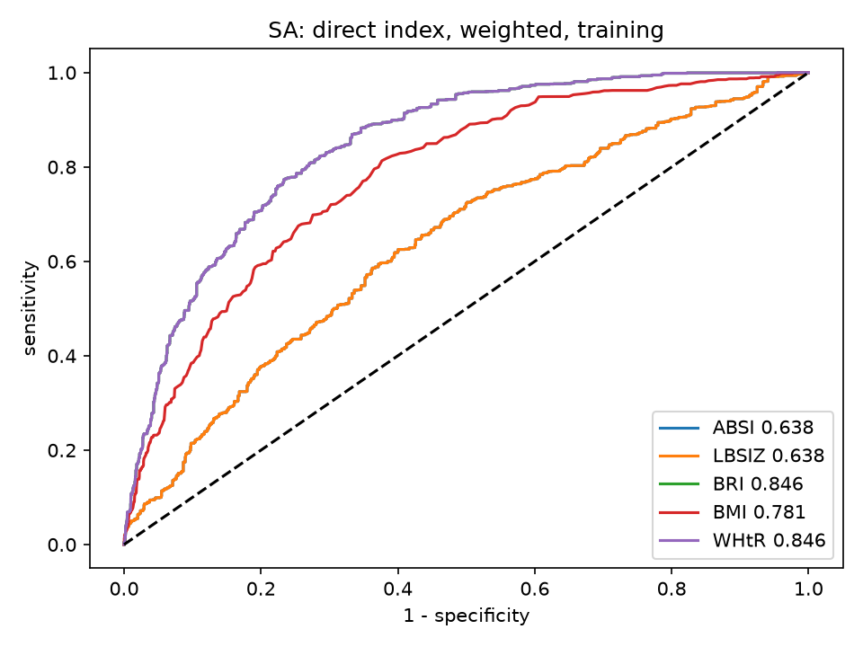

SA · 학습 자료 · 내부 검증 결과는 아래 표

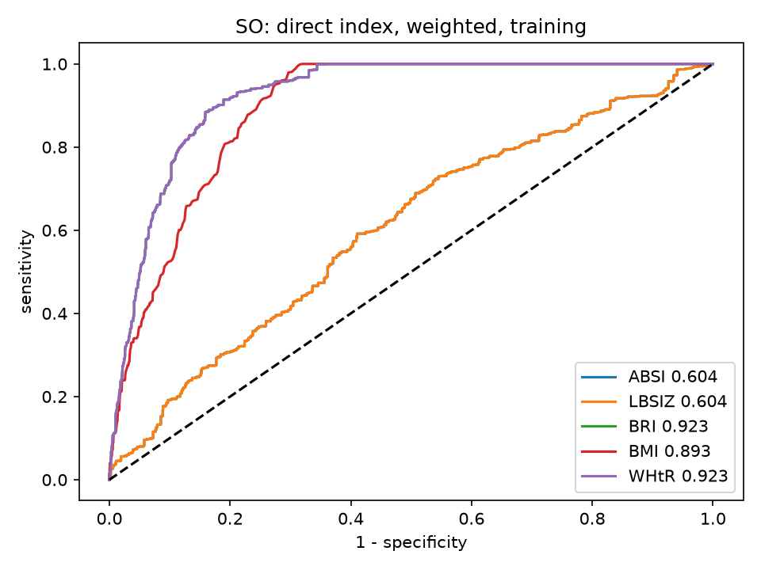

SO · 학습 자료 · 내부 검증 결과는 아래 표

FULL RESULTS

## 회귀 결과와 원문 비교

전체 30개 모형. OR과 CI는 동일한 완전사례와 두 날 식이가중치를 사용한 후보치입니다. **paper_OR은 원문 수치이며 표본·단위·모형의 동등성이 확인되지 않았습니다.** ABSI 0.01, WHtR 0.1, BRI 1, BMI 1 kg/m², LBSIZ 1 SD 증가당 OR입니다.

회귀 대조 전체 CSV 내려받기

| outcome | index | increment | model | n | events | OR | CI_low | CI_high | p | design_df | paper_OR |
| --- | --- | --- | --- | --- | --- | --- | --- | --- | --- | --- | --- |
| SA | ABSI_001 | 0.010 | 1 | 8086 | 687 | 3.239 | 2.501 | 4.194 | 6.1e-13 | 61 | 3.170 |
| SA | ABSI_001 | 0.010 | 2 | 8086 | 687 | 2.264 | 1.615 | 3.174 | 1.2e-05 | 49 | 2.340 |
| SA | ABSI_001 | 0.010 | 3 | 8086 | 687 | 2.008 | 1.418 | 2.845 | 0.00023 | 40 | 2.340 |
| SA | BRI | 1.000 | 1 | 8086 | 687 | 1.610 | 1.544 | 1.679 | 2e-31 | 61 | 1.570 |
| SA | BRI | 1.000 | 2 | 8086 | 687 | 1.711 | 1.619 | 1.807 | 7.2e-25 | 49 | 1.660 |
| SA | BRI | 1.000 | 3 | 8086 | 687 | 1.709 | 1.614 | 1.809 | 1.4e-21 | 40 | 1.670 |
| SA | BMI | 1 kg/m2 | 1 | 8086 | 687 | 1.138 | 1.124 | 1.152 | 2e-29 | 61 | 1.130 |
| SA | BMI | 1 kg/m2 | 2 | 8086 | 687 | 1.157 | 1.137 | 1.177 | 2.7e-22 | 49 | 1.150 |
| SA | BMI | 1 kg/m2 | 3 | 8086 | 687 | 1.154 | 1.133 | 1.174 | 3e-19 | 40 | 1.150 |
| SA | WHtR_01 | 0.100 | 1 | 8086 | 687 | 3.496 | 3.153 | 3.876 | 5.2e-33 | 61 | 3.300 |
| SA | WHtR_01 | 0.100 | 2 | 8086 | 687 | 4.136 | 3.588 | 4.768 | 2.8e-25 | 49 | 3.850 |
| SA | WHtR_01 | 0.100 | 3 | 8086 | 687 | 4.134 | 3.566 | 4.792 | 5.7e-22 | 40 | 3.930 |
| SA | LBSIZ | 1 SD | 1 | 8086 | 687 | 1.690 | 1.503 | 1.900 | 1e-12 | 61 | 1.040 |
| SA | LBSIZ | 1 SD | 2 | 8086 | 687 | 1.436 | 1.233 | 1.673 | 1.7e-05 | 49 | 1.030 |
| SA | LBSIZ | 1 SD | 3 | 8086 | 687 | 1.360 | 1.164 | 1.590 | 0.00028 | 40 | 1.030 |
| SO | ABSI_001 | 0.010 | 1 | 8086 | 479 | 2.568 | 1.914 | 3.447 | 2.3e-08 | 61 | 2.480 |
| SO | ABSI_001 | 0.010 | 2 | 8086 | 479 | 1.743 | 1.211 | 2.508 | 0.0035 | 49 | 1.790 |
| SO | ABSI_001 | 0.010 | 3 | 8086 | 479 | 1.462 | 1.015 | 2.106 | 0.042 | 40 | 1.780 |
| SO | BRI | 1.000 | 1 | 8086 | 479 | 1.848 | 1.741 | 1.962 | 4.1e-29 | 61 | 1.760 |
| SO | BRI | 1.000 | 2 | 8086 | 479 | 1.990 | 1.845 | 2.146 | 1.6e-23 | 49 | 1.890 |
| SO | BRI | 1.000 | 3 | 8086 | 479 | 1.995 | 1.846 | 2.155 | 7.8e-21 | 40 | 1.910 |
| SO | BMI | 1 kg/m2 | 1 | 8086 | 479 | 1.198 | 1.179 | 1.219 | 2.8e-30 | 61 | 1.180 |
| SO | BMI | 1 kg/m2 | 2 | 8086 | 479 | 1.225 | 1.198 | 1.252 | 1.4e-23 | 49 | 1.210 |
| SO | BMI | 1 kg/m2 | 3 | 8086 | 479 | 1.224 | 1.197 | 1.250 | 2e-21 | 40 | 1.210 |
| SO | WHtR_01 | 0.100 | 1 | 8086 | 479 | 5.315 | 4.548 | 6.211 | 4.4e-30 | 61 | 4.670 |
| SO | WHtR_01 | 0.100 | 2 | 8086 | 479 | 6.627 | 5.390 | 8.147 | 1.2e-23 | 49 | 5.730 |
| SO | WHtR_01 | 0.100 | 3 | 8086 | 479 | 6.717 | 5.449 | 8.280 | 4e-21 | 40 | 5.890 |
| SO | LBSIZ | 1 SD | 1 | 8086 | 479 | 1.523 | 1.334 | 1.739 | 3.1e-08 | 61 | 1.030 |
| SO | LBSIZ | 1 SD | 2 | 8086 | 479 | 1.279 | 1.086 | 1.506 | 0.0039 | 49 | 1.020 |
| SO | LBSIZ | 1 SD | 3 | 8086 | 479 | 1.182 | 1.004 | 1.391 | 0.045 | 40 | 1.020 |

## ROC와 컷오프 비교

컷오프는 학습 자료의 Youden 최댓값이며 검증에 고정했습니다. 논문 Table 4에는 컷오프가 없습니다. 원문 AUC와 단순 지표 AUC는 직접 비교 가능한 동일 모형으로 확인되지 않았습니다.

ROC 대조 전체 CSV 내려받기

| outcome | index | train_n | test_n | train_auc | paper_auc | cutoff | train_youden | train_sensitivity | train_specificity | test_auc | test_sensitivity | test_specificity |
| --- | --- | --- | --- | --- | --- | --- | --- | --- | --- | --- | --- | --- |
| SA | ABSI | 6468 | 1618 | 0.638 | 0.759 | 0.081 | 0.225 | 0.625 | 0.600 | 0.642 | 0.572 | 0.609 |
| SA | LBSIZ | 6468 | 1618 | 0.638 | 0.758 | 0.284 | 0.225 | 0.625 | 0.600 | 0.642 | 0.572 | 0.609 |
| SA | BRI | 6468 | 1618 | 0.846 | 0.867 | 5.994 | 0.540 | 0.774 | 0.766 | 0.823 | 0.753 | 0.752 |
| SA | BMI | 6468 | 1618 | 0.781 | 0.835 | 29.100 | 0.436 | 0.813 | 0.623 | 0.739 | 0.717 | 0.629 |
| SA | WHtR | 6468 | 1618 | 0.846 | 0.862 | 0.625 | 0.540 | 0.774 | 0.766 | 0.823 | 0.753 | 0.752 |
| SO | ABSI | 6468 | 1618 | 0.604 | 0.742 | 0.080 | 0.184 | 0.729 | 0.455 | 0.654 | 0.754 | 0.471 |
| SO | LBSIZ | 6468 | 1618 | 0.604 | 0.741 | -0.059 | 0.184 | 0.729 | 0.455 | 0.654 | 0.754 | 0.471 |
| SO | BRI | 6468 | 1618 | 0.923 | 0.855 | 6.706 | 0.726 | 0.885 | 0.841 | 0.909 | 0.802 | 0.841 |
| SO | BMI | 6468 | 1618 | 0.893 | 0.825 | 30.100 | 0.683 | 0.999 | 0.684 | 0.879 | 1.000 | 0.679 |
| SO | WHtR | 6468 | 1618 | 0.923 | 0.857 | 0.654 | 0.726 | 0.885 | 0.841 | 0.909 | 0.802 | 0.841 |

PUBLISHED EVIDENCE

## 논문 근거와 원문 보고값

# 7주차 논문 근거 정리

출처: `논문.pdf`, Wu X, Chen Z, Zhao Y, Ren H. Scientific Reports 14:31776 (2024), doi:10.1038/s41598-024-82751-7. 아래 쪽수는 PDF의 실제 쪽수다. 원문 보고와 재현 후보를 구별했다.

## 연구 설계·선정 (2–3쪽, Figure 1)

횡단면 연구이며 2011–2018년 DXA를 주 분석, 2001–2004년 BIA를 별도 검증에 사용했다고 보고한다. 표본 흐름은 39,156명 → 20세 미만 16,539명과 DXA 결측 10,486명 제외 → 12,131명 → 체형(body type) 결측 1,971명, 에너지 섭취 및 신체활동 결측 2,001명 제외 → 최종 8,159명. 각 단계의 변수 목록과 결측 적용 순서의 세부 코드 및 기타 공변량 결측 규칙은 명시되지 않았다.

## 대상 질환 및 지표 (3–4쪽)

논문은 DXA의 total skeletal muscle mass/BMI가 남성 0.789 미만, 여성 0.512 미만이면 SA로 정의하고, SA이면서 BMI ≥30이면 SO로 정의했다. 실제로 DXA의 어떤 열을 어떻게 더했는지 이 본문 표현만으로 확정하지 못한다. FNIH 기준을 근거로 사지 제지방량 합을 쓰는 것은 검증할 후보이며 저자 코드라고 단정하지 않는다. 근력·신체 기능을 포함하지 않은 이 조작적 정의와 임상 진단 전체는 구별한다.

WHtR=허리둘레(m)/키(m), BMI=체중(kg)/키(m)², ABSI=허리둘레(m)/(BMI^(2/3)×키(m)^(1/2)), BRI=364.2−365.5√[1−{허리둘레(m)/(2π)}²/{0.5×키(m)}²], LBSIZ=[log(ABSI)−평균 log(ABSI)]/표준편차 log(ABSI). LBSIZ의 평균·표준편차를 어떤 모집단과 가중 방식으로 계산했는지는 더 확인해야 한다. 예측 분석에서는 학습 자료의 값을 고정해 검증 자료에 적용한다.

식이는 2일 일평균 에너지·단백질, 좌식 시간은 <4, 4–6, 6–8, >8시간의 4범주로 설명한다(3쪽). 정확한 경계값·불응·결측 코딩은 확인이 필요하다. BMI가 SA 판정과 SO 판정에 직접 들어가므로 BMI 관련 지표의 분류 성능에는 결과 정의와의 수학적 공유가 있다.

## 통계 및 모델 (4·6쪽)

R 4.3.3과 survey 패키지로 전 분석에 가중치를 적용했다고 기술한다(4쪽). Table 3 모델 1은 단변량, 모델 2는 연령·성별·인종·빈곤·교육, 모델 3은 모델 2 변수에 고혈당·고혈압·고콜레스테롤·신체활동 부족·좌식 시간·열량 및 단백질 섭취를 추가한다(6쪽). 세부 범주화, 참조군, 정확한 지표 증가 단위, 선택된 가중치·층·PSU·분산 추정 및 각 모델의 분모는 원문에서 충분히 식별되지 않는다. 표의 별표는 p<0.05이며 정확한 p값은 표시되지 않는다.

### Table 3의 원문 보고 OR (95% CI), 6쪽

| 결과 | 지표 | Model 1 | Model 2 | Model 3 |
| --- | --- | --- | --- | --- |
| SA | ABSI | 3.17 (2.43–4.12) | 2.34 (1.74–3.17) | 2.34 (1.71–3.19) |
| SA | BRI | 1.57 (1.51–1.63) | 1.66 (1.58–1.74) | 1.67 (1.59–1.76) |
| SA | BMI | 1.13 (1.12–1.15) | 1.15 (1.13–1.17) | 1.15 (1.14–1.17) |
| SA | WHtR | 3.30 (2.99–3.64) | 3.85 (3.40–4.36) | 3.93 (3.45–4.48) |
| SA | LBSIZ | 1.04 (1.03–1.05) | 1.03 (1.02–1.04) | 1.03 (1.02–1.04) |
| SO | ABSI | 2.48 (1.85–3.32) | 1.79 (1.29–2.49) | 1.78 (1.27–2.49) |
| SO | BRI | 1.76 (1.68–1.85) | 1.89 (1.78–2.00) | 1.91 (1.79–2.03) |
| SO | BMI | 1.18 (1.17–1.20) | 1.21 (1.19–1.23) | 1.21 (1.19–1.24) |
| SO | WHtR | 4.67 (4.13–5.29) | 5.73 (4.91–6.69) | 5.89 (5.02–6.92) |
| SO | LBSIZ | 1.03 (1.02–1.04) | 1.02 (1.01–1.03) | 1.02 (1.01–1.03) |

## ROC, 분할과 Table 4 (4·6–7쪽)

논문은 단계적 회귀 선택 후 지표별 예측모형을 만들고 8:2로 학습·검증했다고 기술하며 Figure 2는 학습 집합의 곡선이다. 정확한 최종 모형식·변수선택 규칙·랜덤 시드·층화·ROC 가중 및 CI 계산법은 본문에서 충분히 확인되지 않는다. 외부 시간·기관 표본으로 완전히 독립적인 검증이라고 표현하지 않는다. ROC에 사용하는 입력이 단일 지표인지 보정된 모형의 예측값인지에 따라 AUC와 컷오프가 다르다.

Table 4에는 AUC·95% CI·Youden·민감도·특이도가 있으며 **컷오프 값은 없다**. 아래 표는 원문 보고값이다. J=민감도+특이도−1이며 표의 반올림으로 마지막 자리가 다를 수 있다.

| 결과 | 지표 | AUC | 95% CI | J | 민감도 | 특이도 |
| --- | --- | --- | --- | --- | --- | --- |
| SA | ABSI | 0.759 | 0.74–0.78 | 0.40 | 0.68 | 0.72 |
| SA | LBSIZ | 0.758 | 0.74–0.78 | 0.39 | 0.67 | 0.72 |
| SA | BRI | 0.867 | 0.85–0.88 | 0.58 | 0.81 | 0.77 |
| SA | BMI | 0.835 | 0.82–0.85 | 0.52 | 0.83 | 0.69 |
| SA | WHtR | 0.862 | 0.85–0.88 | 0.55 | 0.79 | 0.76 |
| SO | ABSI | 0.742 | 0.72–0.76 | 0.37 | 0.56 | 0.81 |
| SO | LBSIZ | 0.741 | 0.72–0.76 | 0.37 | 0.56 | 0.81 |
| SO | BRI | 0.855 | 0.84–0.87 | 0.55 | 0.85 | 0.70 |
| SO | BMI | 0.825 | 0.81–0.84 | 0.50 | 0.77 | 0.73 |
| SO | WHtR | 0.857 | 0.84–0.87 | 0.54 | 0.83 | 0.71 |

BRI는 WHtR의 단조 변환이므로 같은 사람·가중치·방향에서 각 지표를 직접 점수로 쓰면 ROC와 AUC는 같아야 한다. 원문 표에서는 둘의 AUC가 달라, 단순 지표 ROC라고 확정하지 말고 예측모형 등 보고되지 않은 차이를 조사한다. 이것만으로 저자 오류나 특정 모형을 단정할 수 없다.

## 해석 범위

횡단면 연관과 동시점 구분 성능은 미래 발병 예측이나 인과효과를 증명하지 않는다. 본문의 6쪽 RCS 결과 문단에 이 논문 결과와 다른 수면무호흡·코골이 문구가 있어 해당 부분은 문맥상 불일치로 기록한다. 논문에서 2011–2018 전체에 대해 20세 이상이라 적더라도 DXA 참여 가능 연령의 공식 코드북 범위와 결측에 따른 적용 대상을 확인해야 한다.

QUALITY & LIMITATIONS

## 검토 범위와 남은 일

- 논문의 정확한 제외 규칙, 근육량 DXA 열 구성, 건강 공변량 코딩, 가중치와 OR 단위는 불명확합니다. 자가보고 질병은 대체 변수입니다.
- SA/SO에 BMI가 들어가므로 BMI 지표의 성능은 정의상 공유되는 정보를 반영할 수 있습니다. LBSIZ 표준화를 분할 전에 시행한 컷오프는 정보 누출 가능성이 있습니다.
- 초기 실행 candidate_20261108의 회귀 30개는 인덱싱 오류로 실패했습니다. v2에서 수정 후 새 실행했으며, 결과 30개 상태와 CI·p값 내부 일관성을 독립 검토했습니다. 독립 survey 패키지 수치 대조는 아직 하지 않았습니다.
- 논문의 단계적 예측모형 재현, ROC 신뢰구간 및 2001–2004 BIA 별도 검증은 미완료입니다. 원자료 전체 8,086명의 개별 분석 데이터는 이 보고서에 내장되지 않았습니다. 재생성할 원자료·코드·해시는 로컬 analysis 폴더에 있습니다.

원문: Wu et al. Scientific Reports 14:31776 (2024), DOI 10.1038/s41598-024-82751-7. CDC [NHANES 가중치 안내](https://wwwn.cdc.gov/nchs/nhanes/tutorials/weighting.aspx). 내부 검토는 외부 표본 검증이 아닙니다.

**학습 문서 원문 보기**

**01-concept 연구와 변수.md**

```
# 연구 질문과 한 사람의 자료

NHANES는 여러 단계로 사람을 추출한 횡단면 조사다. 한 행은 한 참가자이며 SEQN으로 인구학, 검사, 식이, 설문을 연결한다. 결과는 같은 시점의 낮은 근육량 분류와 지표 사이의 연관 및 구분 능력이다. 미래에 생길 질병이나 원인 효과를 직접 보여주지 않는다.

예를 들어 한 사람의 허리둘레가 90 cm, 키가 170 cm면 WHtR=0.90/1.70≈0.529다. 이 값은 개인의 입력이다. 회귀 OR과 ROC는 전체 사람들의 자료로 계산하며 이 예시 한 사람의 효과가 아니다.

BMI가 질환 기준과 지표에 동시에 들어가면 변수들이 정의상 정보를 공유한다. 이때 높은 판별력이 지표의 독립적인 임상적 유용성만을 의미하지 않는다.
```

**01-paper 연구와 변수.md**

```
# 논문의 자료와 후보 집단

PDF 2–4쪽: 2011–2018 DXA 자료를 주 분석에 사용하고, 논문 Figure 1의 39,156명에서 최종 8,159명을 선정했다. 2001–2004 BIA는 별도 검증이다. SA 기준은 근육량/BMI 남성 <0.789, 여성 <0.512이고 SO는 SA와 BMI ≥30이다. 임상 진단 전체와는 구별한다.

이번 후보는 사지 제지방량 합을 근육량 대용으로 썼으며, 논문에서 정확한 DXA 변수 조합은 확인되지 않았다. 기본 측정가능자 10,745명에서 모든 후보 공변량 및 양의 2일 식이가중치가 있는 8,086명을 선택했다. 이 중 SA 687명, SO 479명이다. 논문의 세부 선정 및 건강변수 코딩이 미보고여서 73명 차이의 원인을 특정할 수 없다.

후보 공변량은 `../analysis/data/derived/covariates_candidate_설명.md`를 확인한다. 당뇨·고혈압·고콜레스테롤 자가보고는 논문 변수와 일치가 검증되지 않은 대체치다.
```

**02-concept 로지스틱 회귀와 표본설계.md**

```
# 가중 로지스틱 회귀 읽기

로짓은 log(p/(1−p))이고 지표 계수 β를 지수화한 exp(β)가 해당 지표의 정해진 증가 단위에 대한 오즈비(OR)다. OR 1.5는 다른 변수 고정 시 오즈가 1.5배라는 뜻이며, 위험확률이 반드시 1.5배라는 뜻은 아니다. 95% CI는 추정의 불확실성을 보여준다. p값은 귀무가설과 자료의 불일치 정도이며 효과의 크기나 인과성 자체가 아니다.

가중치는 표본의 대표성을 조정하고, 층·PSU는 불확실성을 계산할 때 조사 설계에 반영한다. 단순 가중 GLM의 기본 표준오차는 층화·군집을 반영한 표준오차와 같다고 가정할 수 없다. 선택된 사람만 남긴 뒤 설계 밖 PSU를 없애지 않도록 도메인 분석에 주의한다.
```

**02-paper 회귀 결과.md**

```
# Table 3: 후보 회귀와 원문

논문 모델 1은 단변량, 2는 인구학 변수, 3은 건강·활동·식이를 추가한다. 이번 분석은 세 모델 모두 동일한 8,086명 완전사례에 2일 식이가중치 WTDR2D/4를 사용했다. 가중 우도에 층별 PSU 점수의 Taylor 선형화 분산과 t 자유도를 적용했다. 저자의 실제 가중치와 공변량 세부 정의는 확인되지 않았다.

예: SA의 BRI 1 증가당 모델 3 OR은 **1.709 (95% CI 1.614–1.809, p<0.001)**, 논문은 **1.67 (1.59–1.76)**이다. 수치가 비슷해도 표본과 정의가 달라 정확 재현은 아니다. ABSI는 0.01 증가, WHtR는 0.1 증가를 분석자가 지정했으며 논문 표의 증가 단위는 확인되지 않았다. LBSIZ도 표준화 기준이 다를 수 있어 단위 일치 없이 비교하지 않는다.

30개 결과: `../analysis/runs/candidate_20261108_v2/survey_or.csv`. 전체 원문 수치 및 대조: `../analysis/runs/candidate_20261108_v2/table3_comparison.csv`와 `../논문 근거.md`. 산출된 p값은 후보 모델에 대한 값이며 원문의 표는 정확한 p값 대신 유의성 표시만 제공한다. 표본 설계 추정 구현은 코드 수준 검토를 받았지만 별도 survey 패키지와의 수치 대조는 수행하지 않았다.
```

**03-concept ROC와 검증.md**

```
# ROC와 Youden 지수

민감도는 실제 양성 중 양성으로 분류한 비율, 특이도는 실제 음성 중 음성으로 분류한 비율이다. ROC는 여러 컷오프의 민감도와 1−특이도를 연결하며 AUC는 양성과 음성의 점수를 얼마나 잘 구분하는지 요약한다. Youden 지수 J=민감도+특이도−1이다.

학습 자료에서 J를 최대화하는 컷오프를 선택한 뒤 검증 자료에는 그 값을 고정한다. 검증 자료에서 다시 최적화하면 성능이 낙관적일 수 있다. 같은 조사 자료를 무작위로 나눈 검증은 내부 검증이며 외부 표본의 독립 검증이 아니다. 가중 ROC의 불확실성은 복합표본 설계를 반영해 별도로 추정해야 한다.
```

**03-paper ROC 결과와 한계.md**

```
# Table 4와 ROC: 후보 직접 지표 분석

완전사례를 결과별 층화하여 8:2로 나누고 seed 42, WTDR2D 가중치를 사용했다. 학습 6,468명에서 Youden 최대 컷오프를 고르고 검증 1,618명에서 고정 컷오프를 평가했다. 저자 시드·분할·예측모형은 미확인이다. 직접 지표 ROC이므로 단계적 회귀 후 예측모형을 언급한 논문 Table 4의 정확한 재현이 아니다.

SA의 BRI 학습 AUC는 0.846, 검증 AUC는 0.823이며 학습 컷오프 5.994에서 검증 민감도 0.753, 특이도 0.752다. 논문의 SA BRI 학습 AUC는 0.867이다. 컷오프는 원문 Table 4에 없으므로 이 값은 분석자 추정치다. BRI와 WHtR는 단조 변환 관계여서 같은 사람과 가중치에서 직접 지표 ROC가 동일하다. 원문의 두 AUC는 서로 달라 모형 등 미보고 설정을 확인해야 한다.

지표별 결과: `../analysis/runs/candidate_20261108_v2/roc_direct.csv`; 원문과 기술적 대조: `../analysis/runs/candidate_20261108_v2/table4_comparison.csv`; 곡선: `../analysis/runs/candidate_20261108_v2/ROC_SA.png`, `ROC_SO.png`. AUC 신뢰구간과 예측모형 재현은 미완료다. LBSIZ의 평균·표준편차가 분할 전 후보 전체에서 계산됐으므로 컷오프 해석에 정보 누출이 있다. 양의 선형변환이라 순위 기반 AUC에는 영향을 주지 않지만, 새 분석에서는 학습 집합 기준을 고정해야 한다.
```

원문과 분석자 후보를 구분해 읽으세요 · 생성본은 CSV와 그림을 내장하며 인터넷 없이 열 수 있습니다.